# Git/github

Adolfo De Unánue T.

Andrea Fernández

2018-03-07

# Control de versiones con Git

## Introducción

Un controlador de versiones es una herramienta que gestiona los cambios de un conjunto de archivos. Cada conjunto de cambios genera una nueva versión de los archivos. El controlador de versiones permite, además de la gestión de cambios, recuperar una versión vieja de los archivos o un archivo, así como resolver conflictos entre versiones.

Aunque su principal uso es para agilizar la colaboración en el desarrollo de proyectos de *software*, también puede utilizarse para otros fines (como estas notas) e inclusive para trabajar solo (como en una tesis o proyecto).

Especificamente, un controlador de versiones ofrece lo siguiente:

1. Nada de lo que es *“comiteado”* (*commited*, ahorita vemos que es eso) se perderá.
2. Lleva un registro de *quién* hizo *qué* cambios y *cuándo* los hizo.
3. Es *casi* imposible (nota el casi…) sobreescribir los cambios de tu colaborador. El controlador de versiones notificará que hay un **conflicto** y pedirá que lo resuelvas antes de continuar.

En esta clase usaremos `git`, aunque debemos de notar que no es el único controlador de versiones que existe, entre los más populares se encuentran `bazaar`, `mercurial` y `subversion` (Aunque este último pertenece a una diferente clase de controladores de versiones).

## Un poco de inspiración

Git no se debe de confundir con github. Sin embargo, github es una de las razones por las cuáles se ha vuelto tan popular.

[Examinemos](https://github.com/trending) un poco lo que se puede hacer.

Recordemos que Git es un software aparte de Github pero es lo que verdaderamente hace que todo funcione. Vive en tu computadora y puedes trabajarlo en local si así lo deseas.

## Instalación

### Windows

Windows no será el sistema operativo que utilizaremos en este diplomado. Sin embargo, si lo quieren incorporar fuera de la máquina virtual, deberán instalar git y el emulador de consola de éste. [En esta liga](http://msysgit.github.io/) encontrarás el ejecutable para instalar en Windows.

### Linux

#### Fedora

```bash
yum install git-core
```

#### Debian

```bash
apt-get install git
```

### Mac

Hay dos maneras para usuarios de mac.

1. La fácil es instalando *Xcode Command Line Tools*. Si estás en Mavericks (10.9) o superior simplemente puedes hacerlo corriendo `git` en la terminal. Si no lo tienes instalado aún, te prompteará para hacerlo.
2. Si quieres una versión más actualizada, lo puedes instalar vía binarios.Se mantiene un instalador para git OSX Git y está disponible para su descarga [aquí](http://git-scm.com/download/mac).

## Configurando tu git

Abre una terminal y ve a tu carpeta `home`. Ahí, teclea lo siguiente, para establecer el usuario, correo (que usará `Github` para identificarte por ejemplo), si colorea la salida, y qué editor usará por default para resolver conflictos.

```
git config --global user.name "<Tu Nombre>"
git config --global user.email "<Tu correo-e>"
git config --global color.ui "auto"
git config --global core.editor "emacs"  # Recomendado, puede ser otro
```

Para mirar nuestras configuraciones, podemos teclear:

```
git config --list
```

[Para más opciones de configuración usa esta liga.](http://git-scm.com/book/en/Getting-Started-First-Time-Git-Setup)

## Creando un repositorio

El **repositorio** es la carpeta donde `git` guarda y gestiona todas las versiones de los archivos.

Crea una carpeta en tu `$HOME` llamada `big-data-test`, ingresa a ella e inicializa el repositorio con `git init`. ¿Notas algún cambio? ¿Qué comando usarías? Hay una carpeta ahí ¿no la ves? ¿Cómo puedes ver una carpeta oculta?

La carpeta `.git` es la carpeta donde se guarda todo el historial, si la borras, toda la historia del repositorio se perderá.

Podemos verificar que todo esté bien, con el comando `status`.

```
git status
> On branch master
> Initial commit
> nothing to commit (create/copy files and use "git add" to track)
```

## Llevando registro de los cambios a archivo

Crea un archivo llamado `hola.txt` de la siguiente manera (ALERTA: nuevos comandos de **CLI**):

```
touch hola.txt
echo "¡hola mundo!" > hola.txt
git status
```

(Para ver el contenido de `hola.txt` utiliza el comando `cat hola.txt`).

El mensaje de `untracked files` significa que hay archivos en el repositorio de los cuales `git` no está llevando registro, para que `git` lo haga, debes de **agregarlos** (`add`):

```
git add hola.txt
git status
```

Ahora `git` sabe que debe de llevar registro de los cambios de `hola.txt`, pero aún no se *comprometen* los cambios al repositorio (`Changes to be commited: ...`). Para *comitearlos*:

```
git commit -m "Saludando"
```

Usamos la bandera `-m` para agregar un mensaje que nos ayude a recordar más tarde que se hizo y por qué. El mensaje es *obligatorio*.

Si ejecutamos

```
git status
```

nos indica que todo está actualizado (`up to date`). Podemos ver la historia de cambio con `git log`.

Edita `hola.txt` usando emacs, luego, ejecuta `git status`

La parte clave es `no changes added to commit`. Hemos cambiado el archivo, pero aún no están “comprometidas” o guardadas en el repositorio. Para ver que ha cambiado usamos lo siguiente

```
git diff
```

Hagamos `commit` de estos cambios.

```
git commit -m 'actualizamos hola.txt'
```

Pero `git` no nos dejará, ya que no lo agregamos antes al índice del repositorio. Agrégalo y repite el `commit` (¿Recuerdas como hacerlo con los tips de navegación?).

## El flujo de trabajo

Git maneja este flujo:

Modificando los archivos –> `git add` –> en el área de *staging* (listos para *commit*) –> `git commit` –> Repositorio (guardados permanentemente en **tu** computadora.)

Modifica de nuevo `hola.txt`. Observa los cambios y agrégalo. ¿Qué sucede si vuelves a ejecutar `git diff`?

`Git` dice que no hay nada, ya que para `git` no hay diferencia entre el área de *staging* y el último *commit* (llamado `HEAD`). Para ver los cambios, ejecuta

```
git diff --staged
```

esto muestra las diferencias entre los últimos cambios *comiteados* y lo que está en el área de *staging*. Ahora realiza el `commit`, verifica el estatus y revisa la historia.

## Recapitulando. Los verbos más importantes.

### Agregar (Adding)

Cuando haces cambios o agregas archivos o carpetas, quieres ponerlos bajo el controlador de versiones.

Para esto, debes hacerle saber a *git* cuáles son los archivos sobre los cuáles tiene que poner atención (es decir, en lenguaje git, quieres que tracké (**track**) esos cambios y/o archivos).

**Git add** es la operación que permite que agregues (*add*) esos cambios al índice (**index**) (la manera en la que git mantiene el registro de todos los cambios).

Algunos tips para utilizar `git add`

- `git add .` agrega todos los cambios/archivos *nuevos* correspondientes al directorio o subdirectorio en el que estas (¿Recuerdas pwd? Los archivos ahí.)
- `git add -u .` agrega al índice todos los cambios de los archivos que ya estaban en el índice pero que fueron *modificados* en el directorio o subdirectorio en el que estas.
- `git add -A` agrega *todo* [¡tengan cuidado!]

Una vez que agregas unos cambios, se dice que éstos están *staged*. De cualquier modo, puedes cambiar de opinión acerca de los cambios utilizando `git reset HEAD <file>`.

### Comiteando (commiting)

Puedes commitear (**commit**) los cambios que han sido *staged*. Los commits son la manera de decirle a git que ese es un checkpoint. Igual que en juegos de computadora, un commit es un conjunto de cambios que ameritan que git guarde una versión de el repositorio *hasta ese momento*. Esta es la operación en la que realmente sucede el *versionamiento*.

Son, básicamente, **snapshots** de todos los archivos que ya stageaste para comitear.

Cada vez que commiteas, debes de proveer de un mensaje acompañante que resuma los cambios realizados. Al menos, esa es la idea…

Sean amables con sus compañeros de equipo y con **su yo futuro**. Los mensajes de *commit* son útiles en el futuro cuando ya ni recuerdan qué hicieron o por qué.

Lo único que deben hacer es…

```bash
git commit -m "mensaje sencillo, INFORMATIVO y simple aquí"
```

## Explorando el pasado

Podemos ver los cambios entre diferentes **revisiones**, podemos usar la siguiente notación: `HEAD~1`, `HEAD~2`, etc. como sigue:

```
git diff HEAD~1 hola.txt
git diff HEAD~2 hola.txt
```

También podemos utilizar el identificador único (el número enorme que aparece en el `git log`), inténtalo.

Modifiquemos de nuevo el archivo `hola.txt`. ¿Qué tal si nos equivocamos y queremos regresar los cambios? Podemos ejecutar el comando

```
git checkout HEAD hola.txt
```

(Nota que `git` recomienda un *shortcut* para esta operación: `(use "git checkout -- <file>..." to discard changes in working directory)`)

Obviamente aquí podemos regresarnos las versiones que queramos, por lo que podemos utilizar el identificador único o `HEAD~2` por ejemplo.

> **Ejercicio** Recorre el log con `checkout`, observa como cambia el archivo, usando `cat`.

Por último, `git` tiene comandos `mv` y `rm` que deben de ser usados cuando queremos mover o borrar un archivo del repositorio, i.e. `git mv` y `git rm`.

> **Ejercicio** Crea un archivo `adios.txt`, comitealo, has cambios, comitea y luego bórralo. No olvides hacer el último `commit` también.

## Ayuda

Nadie sabe todo. Accesar a la ducumentación siempre es la mejor opción. Poco a poco te aprenderás los verbos de git.

Para accesar al manual de cada verbo solamente escribe en la terminal:

```
$ git help <verb>
$ git <verb> --help
$ man git-<verb>
```

Antes de continuar con [**Github**](http://github.com) quiero recomendar que impriman la que mas les guste de estas ayudas visuales [1](http://jan-krueger.net/wordpress/wp-content/uploads/2007/09/git-cheat-sheet.pdf), [2](http://www.git-tower.com/blog/git-cheat-sheet-detail/), [3](https://github.com/mattharrison/Git-Supervisual-Cheatsheet) o [esta](http://ndpsoftware.com/git-cheatsheet.html) que es interactiva.

El concepto que no alcancé a ver aquí y que es muy poderoso es el de *stash*, pero pueden deducir su comportamiento de la última ayuda visual.

# Github

## ¿Qué cambia de git a github?

Github es un repositorio central, con una interfaz web bonita, pero fuera de eso, nada impediría que trabajen ustedes con su computadora y la de sus amigos usando los comandos que en esta sección vamos a mostrar, ya que `git` es un sistema distribuito de control de versiones y **ningún nodo** tiene preferencia sobre los demás, pero por comodidad, podemos usar **Github** de tal manera.

Los comandos de transporte.

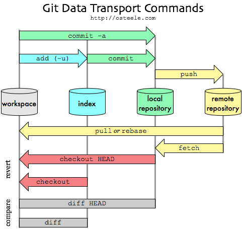

*Figura tomada del [blog de Oliver Steele](http://blog.osteele.com/posts/2008/05/my-git-workflow/).*

Se introducen los verbos de git `clone`, `pull` y `push`.

## Configuración de credenciales

Github siempre pedirá tu contraseña y tu password. Como están trabajando en sus computadoras, no queremos que nos pida una y otra vez las credenciales pues alenta mucho el flujo de trabajo. Nunca dejen sus credenciales en cualquier computadora.

Si no se configuran las credenciales, cada vez que quieras hacer `clone`, `pull` o `push` de un repositorio privado, te pedirá tus credenciales. Dado que el repo del diplomado es privado, configuremos.

### ssh

La opción preferida y segura es via `ssh`. Solo se deben seguir las instrucciones para el sistema operativo de su elección [aquí](https://help.github.com/articles/generating-a-new-ssh-key-and-adding-it-to-the-ssh-agent/).

Y nunca tendrás que introducir tus credenciales. Es la manera más segura de conectar tu versión local de los respositorios con github.

### https

You can also set it up via https and caching your credential by using the [credential helper](https://help.github.com/articles/caching-your-github-password-in-git/)

## El repositorio del diplomado

El repositorio está en:

```
https://github.com/ITAM-DS/diplomado-bbva
```

Lo primero que hay que hacer es **forkear** este repositorio. La operación de `fork` creará una copia de repo de la clase en su usuario de github.

[figure not shown]

Para obtener una copia de trabajo en su computadora deberán de **clonar** su repositorio:

Una vez que tengas configuradas tus credenciales, asegurate de clonar tus repositorios usando el conector ssh apropiado, es decir, vayan al [repo del diplomado](https://github.com/ITAM-DS/diplomado-bbva) y vayan a la sección de *Clone or download* en la esquina superior derecha. Pueden copiar el link directo de la interfaz como se muestra en la imagen.

[figure not shown]

Noten que, si hubieran configurado sus credenciales con **https** y no con **ssh** deberán copiar el otro link (que normalmente es `https://github.com/<usuario-u-organizacion/<nombre-del-repositorio>.git`)

Es importante que sepan de la otra manera de configurar pues, en muchos casos, la conexion por ssh está bloqueada en las empresas y no podrán replicar esa configuración en sus computadoras de trabajo.

Regresando a nuestro caso, el link que copiaron debe verse `git@github.com:<usuario-u-organizacion/<nombre-del-repositorio>.git`.

Después, se van a la terminal, buscan el directorio en el que quieren tener su repositorio y lo clonan ahí.

```
git clone https://github.com/<usuario_github>/diplomado-bbva.git
```

Esto creará una carpeta `diplomado-bbva` en su directorio en el que lo hayan puesto. Por ahora, supongamos que lo clonaron directo en su `$HOME`.

Ve a la carpeta `alumnos` y crea una carpeta cuyo nombre sea tu nombre de usuario en github. En esta carpeta realizarás las tareas, proyectos, etc.

Crea dentro de tu carpeta un archivo que se llame `prueba.txt`, agrégalo, verifica los cambios, has `commit`. El siguiente paso es **subir** los cambios al repositorio de github. Para hacerlo hacemos

```
git push origin master
```

El verbo `push` es el encargado de la acción de subir los cambios. `origin` se refiere al repositorio del cual clonamos la copia local (en nuestra computadora) y `master` se refiere al `branch` (este es un tema avanzado, por ahora ustedes trabajaran siempre en el branch master, que es el default).

Abre tu repositorio en github y observa que tus cambios ahí están. Ahora, vamos a simular que alguien está interactuando con tu repositorio. Desde el sitio web, ve a tu carpeta y has clic en el símbolo de `+` para agregar un archivo (verifica de nuevo que estés en tu carpeta). Llamalo `prueba2.txt` y agrega algo de texto. Para guardar los cambios aprieta el botón `Commit new file`.

En tu computadora, en `docker` en la carpeta `big-data`, para obtener los últimos cambios utiliza:

```
git pull origin master
```

En tu carpeta debería de aparecer el archivo `prueba2.txt`. Ahora quedan por contestar dos preguntas: (1) ¿Cómo actualizo el repositorio `ITAM-DS/diplomado-bbva` (para entregar tarea, por ejemplo) y (2) ¿Cómo actualizo mi repositorio con los cambios del repositorio de `ITAM-DS/diplomado-bbva`? (para bajar las notas que los profesores van subiendo)

Para ambas preguntas es necesario aclarar el concepto de los `remote`: Si ejecutas

```
git remote -v
origin  https://github.com/<usuario>/diplomado-bbva.git (fetch)
origin  https://github.com/<usuario>/diplomado-bbva.git (push)
```

Vamos a agregar como `remote` el repositorio `ITAM-DS/diplomado-bbva`:

```
git remote add diplomado https://github.com/ITAM-DS/diplomado-bbva.git
```

Ejecuta de nuevo `git remote -v`

[output not shown]

Entonces, la respuesta a la primera pregunta (¿cómo entrego mi tarea) es una técnica llamada `pull-request` que en mi conocimiento **solo** se puede realizar desde el navegador. Has click en `Pull Requests` (como se muestra en la imagen) y sigue las instrucciones de la pantalla.

[figure not shown]

Una vez **autorizado** el `pull-request` es necesario hacer

```
git pull diplomado master
git push origin master
```

La primera instrucción baja los cambios del repositorio central a su copia **local** del repositorio, el segundo los sube a su repositorio particular (otra copia pero la versión que guarda github en su fork particular).

Para responder la segunda pregunta (¿cómo bajo lo que han subido otros al repo central?) usamos la misma cadena de comandos:

```
git pull diplomado master
git push origin master
```

Nota que ahora no realizamos un `pull-request`.

## ¿Cuál debería de ser mi *workflow* de trabajo?

En el día a día, se recomienda tener un sano *workflow* de github. Es sencillo y pronto te será muy natural.

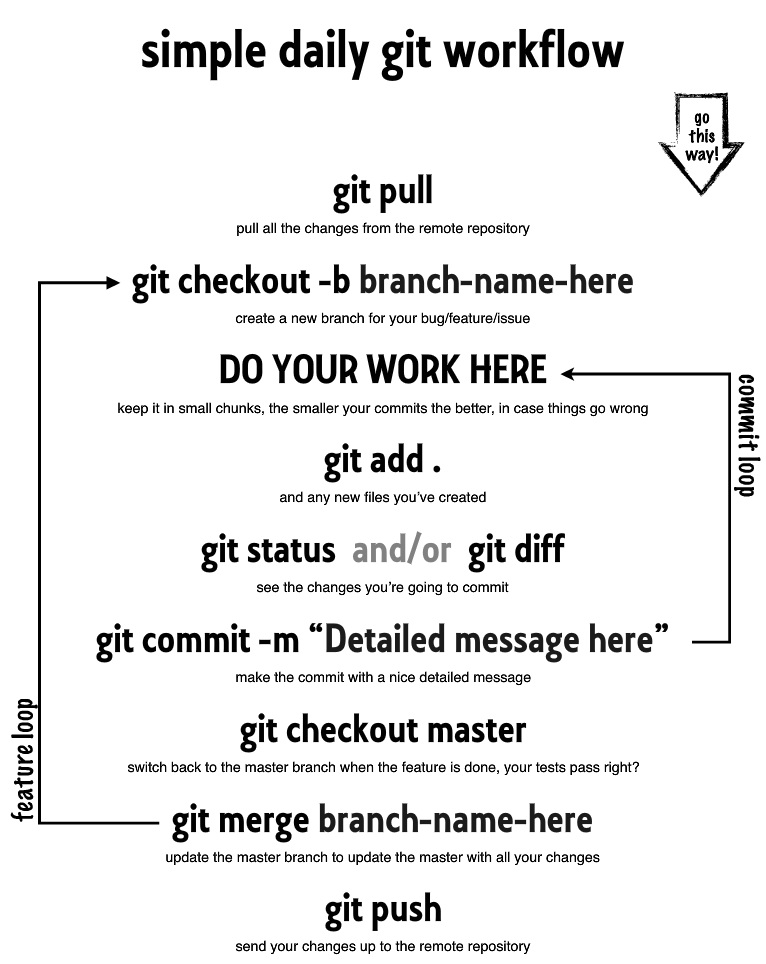

flujo

> Trabajo en equipo usando git

Una posible forma de utilizar un worklow distribuido en equipos es el [Integration Manager Workflow](http://git-scm.com/book/en/Distributed-Git-Distributed-Workflows#Integration-Manager-Workflow). En particular, este es el flujo que utilizaremos en el diplomado pues ustedes no tienen permisos de escribir en el repositorio de clase de manera directa, es decir, siempre deben de pasar por un **pull request** que debe ser autorizado por el profesor.

> **Ejercicio** En esta parte, realizaremos un ejemplo completo del workflow que se espera utilicen para entregar sus tareas y proyectos.

Asumiendo que clonaron en su home (sino vayan al lugar donde tienen el folder del repo).

```
cd diplomado-bbva
git pull origin master # SIEMPRE empezamos con un pull. ¿Por qué?
```

- trabajas en varios archivos
- trabajas
- editas
- hackeas

Y conforme avances (unas cuantas veces al día o cuando por fin algo te salió y funciona)

```
git status
git add <archivos modificados o nuevos>
git commit -m "<comentario acerca de que fue lo que se cambió>"
git push origin master
git status
```

Todo estará bien si

- `git status` respondió con:

```
On branch master
Your branch is up-to-date with 'origin/master'.

nothing to commit, working directory clean
```

- En tu repo están tus cambios.

Cuando quieran enviar la tarea realizan el `pull-request`. Y habrán terminado si en el repositorio `ITAM-DS/diplomado-bbva` están sus cambios. Los profesores no aceptarán sus cambios si su tarea rompe el trabajo de alguien más. Por eso es que estaremos utilizando este workflow.

## .gitignore

`.gitignore` es un archivo específico de texto plano pensado para que no se suban archivos a los repositorios que, aunque pueden ser útiles en el ambiente local, si subimos a github pasara una de las siguientes:

- Github no te lo permitirá pues el archivo es muy grande. Pasa seguido entre los que trabajan con grandes datos.
- Está dentro de los limites de Github pero todos los que comparten repositorio contigo te odiarán pues se tardará siglos en bajar tu actualización.
- Tendras un repositorio muy sucio.

Para eso, está diseñado el archivo `.gitignore` pues, básicamente, permite definir extensiones que por default nunca te mostrará a la hora de pedir un `git status`.

Para *overridear* el `.gitignore` se debe de agregar el archivo con la bandera `-f`. Piensen muy bien antes de hacer esto pero a veces es necesario.

El repositorio que compartimos tiene uno en el *home* [del repo](https://github.com/ITAM-DS/diplomado-bbva/blob/master/.gitignore).

Se pueden poner tantos `.gitignore` como subfolders existan en un repositorio y aplican de arriba hacia abajo, es decir, aplican para el lugar en donde estén y para todas las subcarpetas contenidas en ese directorio.